# Final Paper

STOR 320.01 Group 3

July 22, 2022

# INTRODUCTION

Music stands as one of the tenets of human ingenuity and creativity– we communicate, entertain, and even capitalize on music. In the past decade, the last of those has been explored more thoroughly than the others. The advent of music streaming made it much easier for companies like Apple Music, Tidal, and Spotify to see large profits. Our group decided to look into data from one of these companies providing streaming services, Spotify, which was the earliest of the aforementioned subscription based services to come on the scene. Spotify features millions of songs across every genre imaginable, over the entire lifetime of the music industry, thus providing the perfect backdrop to do in depth analysis on modern music.

Our group was also interested in music popularity. The dataset provided how popular a song was at present (2020 was the current year for the dataset). This led us to question whether we can predict the popularity of a song based on a variety of musical characteristic predictors. Answering these questions could inform us of how the most popular and lucrative musicians in an already extremely profitable field, are able to create three minutes of media that can gross millions of dollars per year over the span of decades, and perhaps provide future artists with the tools to thrive in a service oriented world.

# DATA

Our data was compiled by data.world user Bapiste Mansire. Mansire a current employee at Ippon Technologies, a technology consulting firm. Unfortunately, we do not have the education of Bapiste Mansire however the data was pulled directly from Spotify via api. Therefore, although we are unable to verify the credentials on the source, we trust that the data is raw data from Spotify. The data set contains over 170,000 rows with data from each year (1921 to 2020). The data set contains 19 rows consisting of double, character, and binary variables. Below is the first 10 rows of the data.

| valence | year | acousticness | artists | danceability | duration_ms | energy | explicit | id | instrumentalness | key | liveness | loudness | mode | name | popularity | release_date | speechiness | tempo |
| --- | --- | --- | --- | --- | --- | --- | --- | --- | --- | --- | --- | --- | --- | --- | --- | --- | --- | --- |
| 0.0594 | 1921 | 0.982 | [‘Sergei Rachmaninoff’, ‘James Levine’, ‘Berliner Philharmoniker’] | 0.279 | 831667 | 0.211 | 0 | 4BJqT0PrAfrxzMOxytFOIz | 8.78e-01 | 10 | 0.665 | -20.096 | 1 | Piano Concerto No. 3 in D Minor, Op. 30: III. Finale. Alla breve | 4 | 1921 | 0.0366 | 80.954 |
| 0.9630 | 1921 | 0.732 | [‘Dennis Day’] | 0.819 | 180533 | 0.341 | 0 | 7xPhfUan2yNtyFG0cUWkt8 | 0.00e+00 | 7 | 0.160 | -12.441 | 1 | Clancy Lowered the Boom | 5 | 1921 | 0.4150 | 60.936 |
| 0.0394 | 1921 | 0.961 | [‘KHP Kridhamardawa Karaton Ngayogyakarta Hadiningrat’] | 0.328 | 500062 | 0.166 | 0 | 1o6I8BglA6ylDMrIELygv1 | 9.13e-01 | 3 | 0.101 | -14.850 | 1 | Gati Bali | 5 | 1921 | 0.0339 | 110.339 |
| 0.1650 | 1921 | 0.967 | [‘Frank Parker’] | 0.275 | 210000 | 0.309 | 0 | 3ftBPsC5vPBKxYSee08FDH | 2.77e-05 | 5 | 0.381 | -9.316 | 1 | Danny Boy | 3 | 1921 | 0.0354 | 100.109 |
| 0.2530 | 1921 | 0.957 | [‘Phil Regan’] | 0.418 | 166693 | 0.193 | 0 | 4d6HGyGT8e121BsdKmw9v6 | 1.70e-06 | 3 | 0.229 | -10.096 | 1 | When Irish Eyes Are Smiling | 2 | 1921 | 0.0380 | 101.665 |
| 0.1960 | 1921 | 0.579 | [‘KHP Kridhamardawa Karaton Ngayogyakarta Hadiningrat’] | 0.697 | 395076 | 0.346 | 0 | 4pyw9DVHGStUre4J6hPngr | 1.68e-01 | 2 | 0.130 | -12.506 | 1 | Gati Mardika | 6 | 1921 | 0.0700 | 119.824 |
| 0.4060 | 1921 | 0.996 | [‘John McCormack’] | 0.518 | 159507 | 0.203 | 0 | 5uNZnElqOS3W4fRmRYPk4T | 0.00e+00 | 0 | 0.115 | -10.589 | 1 | The Wearing of the Green | 4 | 1921 | 0.0615 | 66.221 |
| 0.0731 | 1921 | 0.993 | [‘Sergei Rachmaninoff’] | 0.389 | 218773 | 0.088 | 0 | 02GDntOXexBFUvSgaXLPkd | 5.27e-01 | 1 | 0.363 | -21.091 | 0 | Morceaux de fantaisie, Op. 3: No. 2, Prélude in C-Sharp Minor. Lento | 2 | 1921 | 0.0456 | 92.867 |
| 0.7210 | 1921 | 0.996 | [‘Ignacio Corsini’] | 0.485 | 161520 | 0.130 | 0 | 05xDjWH9ub67nJJk82yfGf | 1.51e-01 | 5 | 0.104 | -21.508 | 0 | La Mañanita - Remasterizado | 0 | 1921-03-20 | 0.0483 | 64.678 |
| 0.7710 | 1921 | 0.982 | [‘Fortugé’] | 0.684 | 196560 | 0.257 | 0 | 08zfJvRLp7pjAb94MA9JmF | 0.00e+00 | 8 | 0.504 | -16.415 | 1 | Il Etait Syndiqué | 0 | 1921 | 0.3990 | 109.378 |

After cleaning the data, we found that there was not a single missing value in our data set, confirming the usage of a Spotify api. A few changes were made to the data set for the sake of convenience and further investigation. The data was condensed from 19 variables to 13 variables with the addition 2 more modified variables. Duration_ms was converted from milliseconds to minutes to reduce the size of values when plotting. A new decade variable was created to aggregate data on a decade to decade basis. The data for the year 202 was removed because it introduced potential skew that would interfere with model creation.

### Cleaning Data

| year | decade | popularity | prop_pop | valence | danceability | duration_min | energy | explicit | instrumentalness | liveness | loudness | speechiness | tempo | acousticness |
| --- | --- | --- | --- | --- | --- | --- | --- | --- | --- | --- | --- | --- | --- | --- |
| 1921 | 1920 | 4 | 4.081633 | 0.0594 | 0.279 | 13.861117 | 0.211 | 0 | 8.78e-01 | 0.665 | -20.096 | 0.0366 | 80.954 | 0.982 |
| 1921 | 1920 | 5 | 5.102041 | 0.9630 | 0.819 | 3.008883 | 0.341 | 0 | 0.00e+00 | 0.160 | -12.441 | 0.4150 | 60.936 | 0.732 |
| 1921 | 1920 | 5 | 5.102041 | 0.0394 | 0.328 | 8.334367 | 0.166 | 0 | 9.13e-01 | 0.101 | -14.850 | 0.0339 | 110.339 | 0.961 |
| 1921 | 1920 | 3 | 3.061224 | 0.1650 | 0.275 | 3.500000 | 0.309 | 0 | 2.77e-05 | 0.381 | -9.316 | 0.0354 | 100.109 | 0.967 |
| 1921 | 1920 | 2 | 2.040816 | 0.2530 | 0.418 | 2.778217 | 0.193 | 0 | 1.70e-06 | 0.229 | -10.096 | 0.0380 | 101.665 | 0.957 |
| 1921 | 1920 | 6 | 6.122449 | 0.1960 | 0.697 | 6.584600 | 0.346 | 0 | 1.68e-01 | 0.130 | -12.506 | 0.0700 | 119.824 | 0.579 |
| 1921 | 1920 | 4 | 4.081633 | 0.4060 | 0.518 | 2.658450 | 0.203 | 0 | 0.00e+00 | 0.115 | -10.589 | 0.0615 | 66.221 | 0.996 |
| 1921 | 1920 | 2 | 2.040816 | 0.0731 | 0.389 | 3.646217 | 0.088 | 0 | 5.27e-01 | 0.363 | -21.091 | 0.0456 | 92.867 | 0.993 |
| 1921 | 1920 | 0 | 0.000000 | 0.7210 | 0.485 | 2.692000 | 0.130 | 0 | 1.51e-01 | 0.104 | -21.508 | 0.0483 | 64.678 | 0.996 |
| 1921 | 1920 | 0 | 0.000000 | 0.7710 | 0.684 | 3.276000 | 0.257 | 0 | 0.00e+00 | 0.504 | -16.415 | 0.3990 | 109.378 | 0.982 |

### Odd Cases

| name | artists | release_date | popularity |
| --- | --- | --- | --- |
| Diamonds | Rihanna | 2012-01-01 | 67 |
| Diamonds | Rihanna | 2012-12-11 | 58 |
| Diamonds | Rihanna | 2012-01-01 | 57 |
| Diamonds | Rihanna | 2012-12-11 | 55 |

When analyzing the raw data, we found that there are instances of songs with identical names, artists and release date yet have a different popularity. Our best guess as to which this might occur is that the song could be released in different languages. As for songs with different release dates, we believe that the artist might have rereleased their song. Regardless of the reason, we decided to filter out songs with identical names, artists and release date.

### Popularity problem

Upon initial analysis of popularity, we noticed that the popularity variable displayed strange distribution. According to Spotify’s API dictionary, popularity is measured based on the volume and **recency** of streams. This introduces a new problem in using the popularity variable since popularity will naturally increase as the rececny of the song increases. The popularity variable is volatile and changes based on when the data was pulled. If the data set had included total streams, it might have been a better metric for popularity.

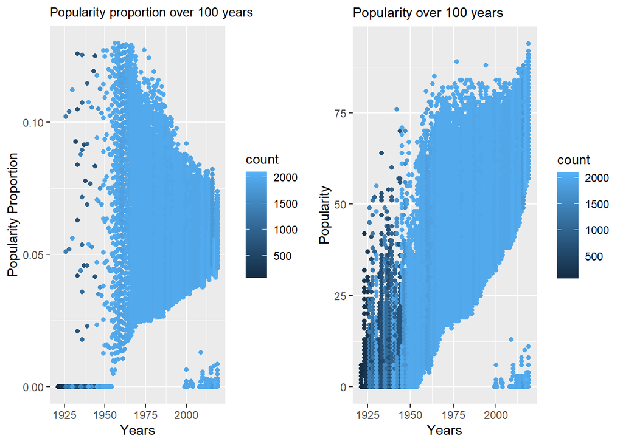

### Variable description

- **year**: The year the song was released in
- **decade**: The decade the song was released in. Aggregated data from year.
- **Popularity**: Double vairable ranging from 1 to 100 based on number of streams and recency of streams.
- **pop_prop**: Proportion of popularity of song within a year.
- **valence**: Double variable ranging from 0 to 1. Measures the musical positiveness. Higher valence = more happy.
- **danceability**: Double variable ranging from 0 to 1. How danceable a song is based on rhythm, beat strength etc.
- **duration_min**: Duration of song in minutes.
- **energy**: Double variable ranging from 0 to 1. Measures the intensity of a song. Ex: Rock songs have higher energy than classical music.
- **explicit**: Binary variable being 0 or 1. 0 - non-explicit. 1 - explicit.
- **instrumentalness**: Double variable ranging from 0 to 1. Measures the sound in music that is not vocal. Oppotsite of speechiness.
- **liveness**: Double variable ranging from 0 to 1.Measures the presence of an audience in the recording. A track performed live will have a higher value than a studio recorded song.
- **loudness**: Double variable measuring decibles of the song
- **speechiness**: Double variable ranging from 0 to 1. Measures presence of words in a track. Rap songs will have high speechiness.
- **tempo**: Double variable measuring beats per minute.
- **acousticness**: Double variable ranging from 0 to 1. How acoustic a song is, the lack of electric instruments.

# RESULTS

## RESULT 1

From the radar plot, we can see that acousticness has progressively gotten lower indicating a shift away from acoustic instruments throughout the decades. Our findings are supported by the fact that digital music production has become very popular recently. There is also a noticeable change in energy from 1920 to 2010 with energy significantly increasing. Such a change indicates that music today is much more intense than music in the past. It is possible that the birth of energetic genres such as rock and club music likely shifted attraction from more reserved genres such as classical music. What we found interesting was that danceability appeared to remain consistent throughout the century suggesting that songs have always been generally danceable.

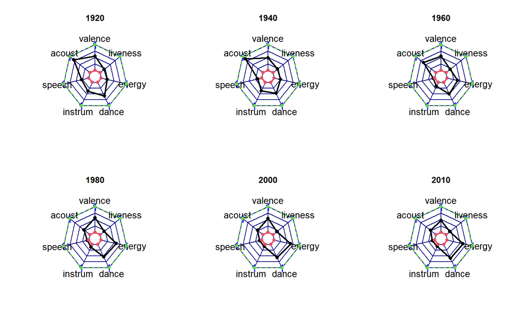

In order to reduce misinterpretations and misguiding visualizations, we decided to create a box plot to further demonstrate how music has changed. The box plots display the distribution of a song’s musical characteristic for each decade. We found that a box plot would allow a more intricate analysis of the data as the mean alone is not enough to make a solid conclusion. The animated plot moves through 7 variables that were also plotted on the radar plot.

- Much like the radar plot, the median acoustics has greatly decreased; however what the radar plot failed to show is that the inter quartile range for the last 5 decades are very high which lead us to conclude that although acousticness has decreased over time, there is still great variation in later decades. This means that there is still plenty of music today with high acousticness.
- As previously mentioned, the energy of music has consistently increased which is supported by the box plot below. Much like acousticness however, the variation of energy has also increased over time suggesting not only an increase in energy but a more diverse range of music energy.
- According to the box plot, the interquartile range for instrumentalness has sharply decreased with the 3 most recent decades having extremely low spread of data. Additionally, the instrumentalness for longs has historically been low and appears to remain that way. What is particularly strange about his distribution is the fact that speechiness has also been historically low with little distribution. Our group initially thought that instrumentalness and speechiness would demonstrate inverse distributions of each other based on what the variables represent. This however is not the case suggesting that instrumentalness does not necessarily go hand in hand with the inverse of speechiness.
- Among the 7 variables plotted, livenss and danceability and valence have exhibited the most stable distribution. Based on these results, we can infer that high danceability and high valence have historically been staples of music.

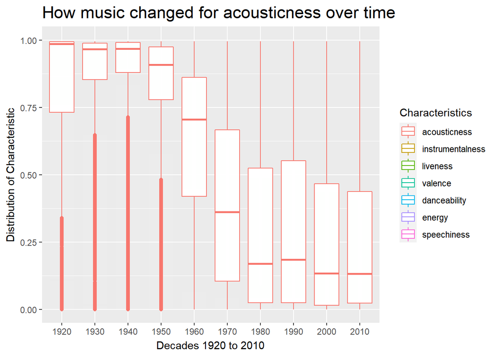

## Result 2 - Linear Models

For our second questions, we wanted to investigate if a musical characteristic or a combination of musical characteristics could predict the popularity proportion of a song. Based on the results from the previous question, we were particularly interested in whether energy would be a better predictor for popularity proportion since songs typically became more energetic over time. We believe that a favorable musical characteristic might be associated with popularity.

- lm_val = lm(prop_pop ~ valence,data=train.music)
- lm_dance = lm(prop_pop ~ danceability,data=train.music)
- lm_dur = lm(prop_pop ~ duration_min,data=train.music)
- lm_nrg = lm(prop_pop ~ energy,data=train.music)
- lm_exp = lm(prop_pop ~ explicit,data=train.music)
- lm_inst = lm(prop_pop ~ instrumentalness,data=train.music)
- lm_live = lm(prop_pop ~ liveness,data=train.music)
- lm_loud = lm(prop_pop ~ loudness,data=train.music)
- lm_spch = lm(prop_pop ~ speechiness,data=train.music)
- lm_tmp = lm(prop_pop ~ tempo,data=train.music)
- lm_acous = lm(prop_pop ~ acousticness,data=train.music)

Below are the RMSE and MAE for each variable

Top 5 Initial RMSE models

| model | RMSE | MAE |
| --- | --- | --- |
| mod_acous | 0.4222523 | 0.0412102 |
| mod_nrg | 0.4223072 | 0.0407983 |
| mod_exp | 0.4223296 | 0.0407386 |
| mod_dance | 0.4223572 | 0.0402760 |
| mod_loud | 0.4223597 | 0.0403095 |
| mod_dur | 0.4223604 | 0.0402723 |

Top 5 Initial MAE models

| model | RMSE | MAE |
| --- | --- | --- |
| mod_spch | 0.4223833 | 0.0401458 |
| mod_inst | 0.4223726 | 0.0402213 |
| mod_live | 0.4223658 | 0.0402423 |
| mod_val | 0.4223755 | 0.0402491 |
| mod_tmp | 0.4223667 | 0.0402626 |
| mod_dur | 0.4223604 | 0.0402723 |

Based on the results from the RMSE and MAE table, 4 variables were chosen for further investigation in the second round. The secondary models are as follows:

- lm_a = lm(prop_pop ~ acousticness + energy,data=train.music)
- lm_b = lm(prop_pop ~ acousticness + speechiness,data=train.music)
- lm_c = lm(prop_pop ~ energy + speechiness,data=train.music)
- lm_d = lm(prop_pop ~ acousticness + instrumentalness,data=train.music)

The lack of significant results from the second round of modelling lead our group to attempt models that fit a certain catagory. The models for the third round of modeling is as follows:

- lm_e = lm(prop_pop ~ acousticness + speechiness + instrumentalness + energy,data=train.music)
- lm_f = lm(prop_pop ~ speechiness + explicit + instrumentalness,data=train.music)
- lm_g = lm(prop_pop ~ acousticness + danceability + tempo + valence + loudness + liveness + energy,data=train.music)

**Model-e** was based on all of the 4 significant variables from the first round. **Model-f** was consisted of variables that were associated with the speechiness of a song. We believe that the explicit and instrumentalness variables share a relation with speechiness. **Model-g** consisted of predictors that were associated with the energy and how upbeat a song is.

Below are the top 5 models according to RMSE and MAE respectively.

Top 5 final RMSE models

| model | RMSE | MAE |
| --- | --- | --- |
| mod_upbeat | 0.4221960 | 0.0416744 |
| mod_acyr | 0.4222522 | 0.0412080 |
| mod_acous | 0.4222523 | 0.0412102 |
| mod_acda | 0.4222604 | 0.0412366 |
| mod_yrex | 0.4222705 | 0.0410502 |
| mod_full | 0.4222836 | 0.0410966 |

Top 5 final MAE models

| model | RMSE | MAE |
| --- | --- | --- |
| mod_spch | 0.4223833 | 0.0401458 |
| mod_inst | 0.4223726 | 0.0402213 |
| mod_live | 0.4223658 | 0.0402423 |
| mod_val | 0.4223755 | 0.0402491 |
| mod_tmp | 0.4223667 | 0.0402626 |
| mod_dur | 0.4223604 | 0.0402723 |

The top models for according to RMSE and MAE were rather unexpected. Not a single model was shared by the two methods of error so our group decided to compare the top models of each by applying a prediction to the testing data set. Two point plots were created for each model with a line of slope = 1 as reference for a perfect prediction. The line does not appear to be at a 45 degree angle because the y-axis and x-axis do not share the name bounds. Unfortunately, based on the graphs below, neither model appears to adequately predict popularity proportion. For the sake of comparison, the Upbeat model appears to at least so a slightly better job predicting the data as the distribution of points appears to be more aligned with the 45 degree angle line.

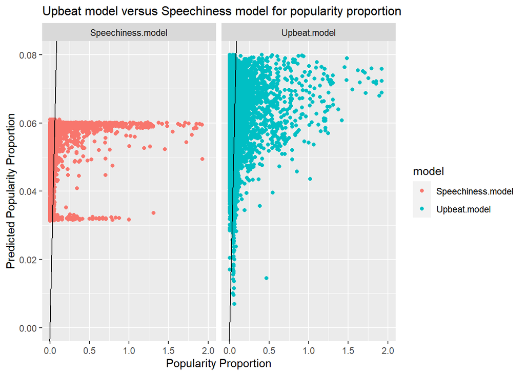

## Result 2 - Lasso Model

```
## The optmal lasso lambda parameter is:  0.01245613
```

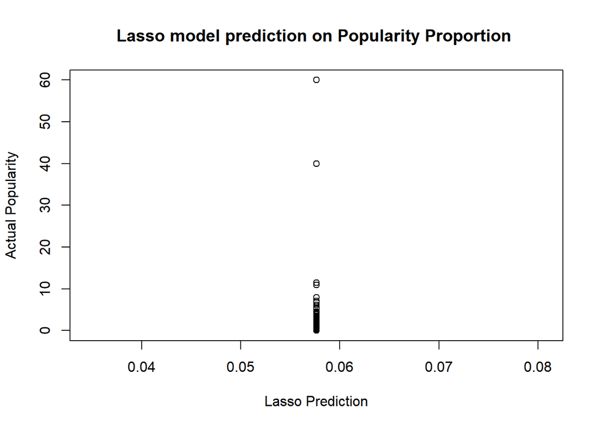

# CONCLUSION

Our analysis of the Spotify dataset attempted to answer two questions. First we looked at how music has changed over time. We found that acousticness, speechiness, and instrumentalness have decreased over the past 100 years, and energy has increased over the years. Other variables featured little to no change. So the components of music have changed with time, but to a varying degree for individual elements. At the time of our group investigating the dataset, the typical song will likely have: very low instrumentalness; low acousticness, liveliness, and speechiness; moderate valence; and high danceability and energy. Given how music has tended to move away from acoustic instruments to production using software, the trends we saw in the different predictors reflect that shift. While there has been a clear change in genres over the past century, knowing the specifics of what a genre change means can tell us about future trends in music. Diving deeper into this data, one could possibly predict how the next generation of music will differ from previous ones.

These questions have very real application to the music and streaming industries. If we can discern and predict the sound of music, as well as predict the popularity of a song, streaming services and artists can better streamline the process of making and distributing music. While it is excellent for consumers that there are millions upon millions of songs available at our fingertips, a company like Spotify will surely want to promote the more popular songs to listeners since those will gross more. Having the knowledge to determine what kind of music will be produced in the future, as well as knowing if a song has the factors to potentially become popular before it is released to the public, could make Spotify an even more profitable and efficient institution.